# Perception of Scientific Visualization

# Line Plots and Line Type

**Line plots** connect discrete, ordered, data points by a line

- Can use different line pattern types to differentiate data
- Only useful for a limited number of lines on one graph
- Too many similar line pattern on one plot leads to viewer confusion and poor perception

# Limits of Line Type

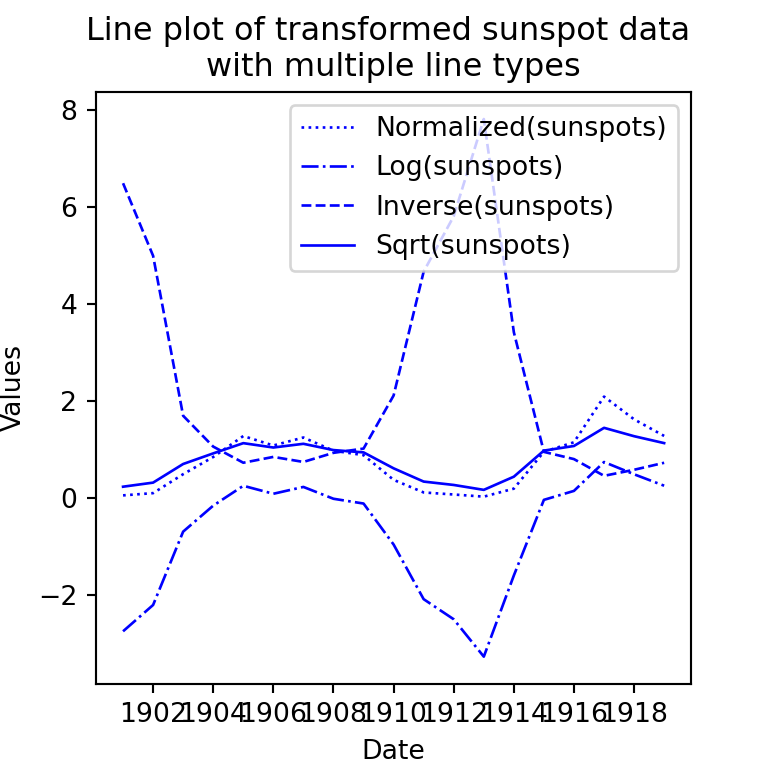

# Marker Shape

**Marker shape** is useful for displaying categorical relationships

- This aesthetic is only useful when two conditions are met:
1. The number of categories is small
2. Distinctive shape are chosen for the markers
- Human perception limits the number of shapes humans can precieve well

# Aspiration by Marker Shape

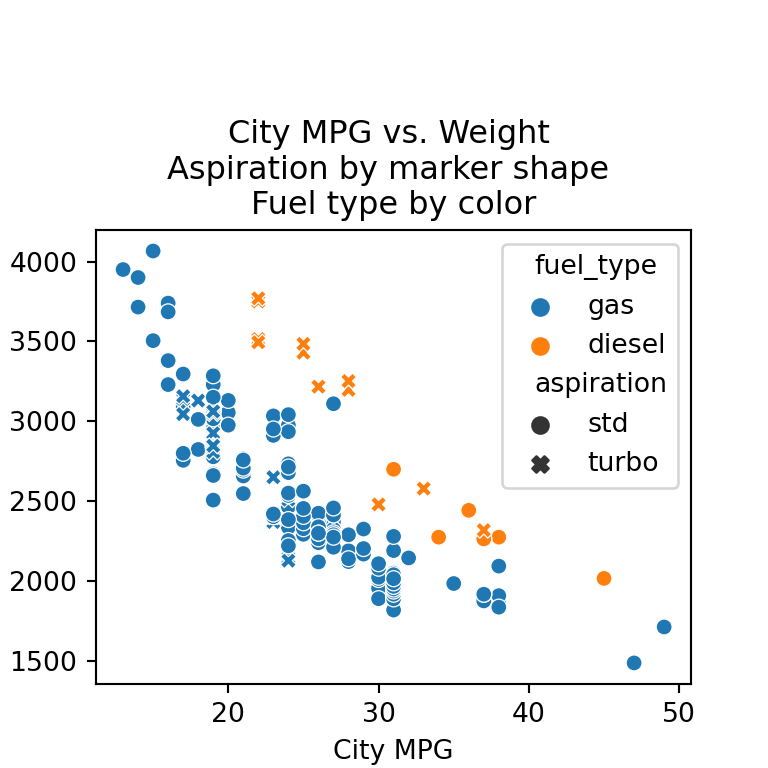

# Summary

We have explored these key points  
- Proper use of plot aesthetics enable projection of multiple dimensions of complex data onto the 2-dimensional plot surface.  
- All plot aesthetics have limitations which must be understood to use them effectively  
- The effectiveness of a plot aesthetic varies with the type and the application